# ANALYSIS ON THE TITANIC DATASET

### Problem Statement:

The sinking of the RMS Titanic on April 15, 1912, remains one of the most infamous maritime disasters in history, capturing the world's attention and sparking numerous studies and inquiries. This tragic event resulted in the loss of many lives among the passengers and crew onboard. The Titanic dataset contains various attributes of passengers, including demographic information and survival status, providing valuable insights into the factors that influenced survival rates.

In this analysis, we delve into the fascinating story of the Titanic disaster, seeking to uncover insights into the survival rates of passengers based on their gender, age, and class on the Titanic.

### Objective:

The objective of this analysis is to explore the Titanic dataset and uncover patterns, trends, and factors that affected the survival of passengers. By examining demographic variables such as age, gender, class, and embarked port, along with other factors like fare paid, we aim to address the following questions:

1. What was the overall survival rate of passengers aboard the Titanic?
2. How did survival rates vary based on demographic factors such as age, gender, and passenger class?
3. Were passengers traveling with family more likely to survive than those traveling alone?
4. Did the fare paid or the deck level have any correlation with survival rates?
5. What role did the embarkation port play in determining survival outcomes?

Through exploratory data analysis and visualization techniques, we seek to gain a deeper understanding of the Titanic disaster and identify potential factors that contributed to the likelihood of survival of passengers, aboard the ill-fated vessel. This analysis aims to provide insights that may contribute to a better understanding of historical events, and contribute to ongoing discussions on the social dynamics for safety measures in maritime travel.

*Join us as we embark on this journey through data, exploring the human stories behind the Titanic tragedy and uncovering insights into gender disparities in survival rates.*

### Project Contributors

```
`1. Daniel McDinna    2. Ifeoluwa Ajayi    3. Suleiman Adisa    4. Enesi Emmanuel    5. Kazeem Ahmed    6. Idowu Saidi`
```

```python
# Let's begin!
#Import neccessary libraries for our analysis and insight exploration on the Dataset

import pandas as pd
import numpy as np
import seaborn as sns
import matplotlib.pyplot as plt
import warnings
warnings.filterwarnings('ignore')
```

```python
#Getting the Dataset and reading it for our analysis

titanic_data=pd.read_csv(r"C:\Users\USER PC\OneDrive\Documents\Business and Education\INGRYD\Project\Titanic-Dataset.csv")
titanic_data
```

|  | PassengerId | Survived | Pclass | Name | Sex | Age | SibSp | Parch | Ticket | Fare | Cabin | Embarked |
| --- | --- | --- | --- | --- | --- | --- | --- | --- | --- | --- | --- | --- |
| 0 | 1 | 0 | 3 | Braund, Mr. Owen Harris | male | 22.0 | 1 | 0 | A/5 21171 | 7.2500 | NaN | S |
| 1 | 2 | 1 | 1 | Cumings, Mrs. John Bradley (Florence Briggs Th... | female | 38.0 | 1 | 0 | PC 17599 | 71.2833 | C85 | C |
| 2 | 3 | 1 | 3 | Heikkinen, Miss. Laina | female | 26.0 | 0 | 0 | STON/O2. 3101282 | 7.9250 | NaN | S |
| 3 | 4 | 1 | 1 | Futrelle, Mrs. Jacques Heath (Lily May Peel) | female | 35.0 | 1 | 0 | 113803 | 53.1000 | C123 | S |
| 4 | 5 | 0 | 3 | Allen, Mr. William Henry | male | 35.0 | 0 | 0 | 373450 | 8.0500 | NaN | S |
| ... | ... | ... | ... | ... | ... | ... | ... | ... | ... | ... | ... | ... |
| 886 | 887 | 0 | 2 | Montvila, Rev. Juozas | male | 27.0 | 0 | 0 | 211536 | 13.0000 | NaN | S |
| 887 | 888 | 1 | 1 | Graham, Miss. Margaret Edith | female | 19.0 | 0 | 0 | 112053 | 30.0000 | B42 | S |
| 888 | 889 | 0 | 3 | Johnston, Miss. Catherine Helen "Carrie" | female | NaN | 1 | 2 | W./C. 6607 | 23.4500 | NaN | S |
| 889 | 890 | 1 | 1 | Behr, Mr. Karl Howell | male | 26.0 | 0 | 0 | 111369 | 30.0000 | C148 | C |
| 890 | 891 | 0 | 3 | Dooley, Mr. Patrick | male | 32.0 | 0 | 0 | 370376 | 7.7500 | NaN | Q |

891 rows × 12 columns

```python
# We delve into the info of the Dataset
titanic_data.info()
```

```
<class 'pandas.core.frame.DataFrame'>
RangeIndex: 891 entries, 0 to 890
Data columns (total 12 columns):
 #   Column       Non-Null Count  Dtype
---  ------       --------------  -----
 0   PassengerId  891 non-null    int64
 1   Survived     891 non-null    int64
 2   Pclass       891 non-null    int64
 3   Name         891 non-null    object
 4   Sex          891 non-null    object
 5   Age          714 non-null    float64
 6   SibSp        891 non-null    int64
 7   Parch        891 non-null    int64
 8   Ticket       891 non-null    object
 9   Fare         891 non-null    float64
 10  Cabin        204 non-null    object
 11  Embarked     889 non-null    object
dtypes: float64(2), int64(5), object(5)
memory usage: 83.7+ KB
```

```python
# Checking for NaN Values in the Dataset
titanic_data.isna()
```

|  | PassengerId | Survived | Pclass | Name | Sex | Age | SibSp | Parch | Ticket | Fare | Cabin | Embarked |
| --- | --- | --- | --- | --- | --- | --- | --- | --- | --- | --- | --- | --- |
| 0 | False | False | False | False | False | False | False | False | False | False | True | False |
| 1 | False | False | False | False | False | False | False | False | False | False | False | False |
| 2 | False | False | False | False | False | False | False | False | False | False | True | False |
| 3 | False | False | False | False | False | False | False | False | False | False | False | False |
| 4 | False | False | False | False | False | False | False | False | False | False | True | False |
| ... | ... | ... | ... | ... | ... | ... | ... | ... | ... | ... | ... | ... |
| 886 | False | False | False | False | False | False | False | False | False | False | True | False |
| 887 | False | False | False | False | False | False | False | False | False | False | False | False |
| 888 | False | False | False | False | False | True | False | False | False | False | True | False |
| 889 | False | False | False | False | False | False | False | False | False | False | False | False |
| 890 | False | False | False | False | False | False | False | False | False | False | True | False |

891 rows × 12 columns

```python
#Get an numerical data on the NaN Values in the Dataset

titanic_data.isna().sum()
```

```
PassengerId      0
Survived         0
Pclass           0
Name             0
Sex              0
Age            177
SibSp            0
Parch            0
Ticket           0
Fare             0
Cabin          687
Embarked         2
dtype: int64
```

```python
# Get the full description on the Dataset

titanic_data.describe()
```

|  | PassengerId | Survived | Pclass | Age | SibSp | Parch | Fare |
| --- | --- | --- | --- | --- | --- | --- | --- |
| count | 891.000000 | 891.000000 | 891.000000 | 714.000000 | 891.000000 | 891.000000 | 891.000000 |
| mean | 446.000000 | 0.383838 | 2.308642 | 29.699118 | 0.523008 | 0.381594 | 32.204208 |
| std | 257.353842 | 0.486592 | 0.836071 | 14.526497 | 1.102743 | 0.806057 | 49.693429 |
| min | 1.000000 | 0.000000 | 1.000000 | 0.420000 | 0.000000 | 0.000000 | 0.000000 |
| 25% | 223.500000 | 0.000000 | 2.000000 | 20.125000 | 0.000000 | 0.000000 | 7.910400 |
| 50% | 446.000000 | 0.000000 | 3.000000 | 28.000000 | 0.000000 | 0.000000 | 14.454200 |
| 75% | 668.500000 | 1.000000 | 3.000000 | 38.000000 | 1.000000 | 0.000000 | 31.000000 |
| max | 891.000000 | 1.000000 | 3.000000 | 80.000000 | 8.000000 | 6.000000 | 512.329200 |

```python
'''Age is an important part of our analysis and has 177 NaN Values.
- From the description above our Mean value for Age is: 29.699118.
- We resolved that filling the NaN Values in the Age Column with the median value is best fit, with the skewness in mind.
- Let us Get the median value for the Age Column!
- Let median_age be the median of the Age column'''

median_age = titanic_data['Age'].median()
median_age
```

```
28.0
```

```python
# fill NaN values in the Age column with the median age.
titanic_data['Age'].fillna(median_age, inplace=True)
```

```python
# Check last operation

titanic_data['Age'].isna().sum()
```

```
0
```

```python
'''Cabin is not so important for our analysis and has 687 NaN Values.
- We resolved that filling the NaN Values in the Cabin Column with the mode value is best fit, with the skewness in mind.
- Let us Get the mode value for the Cabin Column!
- Let cabin_mode be the mode of the Cabin column.'''

cabin_mode = titanic_data['Cabin'].mode()
cabin_mode
```

```
0        B96 B98
1    C23 C25 C27
2             G6
Name: Cabin, dtype: object
```

```python
# Until we descide to either drop the Cabin colum or not...
# Fill the categorical Cabin column with the index 2 value of the mode value in the Cabin column

titanic_data['Cabin'].fillna(cabin_mode[2], inplace=True)
```

```python
# Check last operation

titanic_data['Cabin'].isna().sum()
```

```
0
```

```python
'''To be descided later on!'''
# titanic_data.drop('Cabin', axis =1, inplace = True)
```

```
'To be descided later on!'
```

```python
# filling the categorical Embarked colunm, first we get the mode
Embarked_mode = titanic_data['Embarked'].mode()
Embarked_mode
```

```
0    S
Name: Embarked, dtype: object
```

```python
titanic_data['Embarked'].fillna(Embarked_mode[0], inplace=True)
titanic_data['Embarked'].isna().sum()
```

```
0
```

```python
# Check for the cleaness of the dataset

titanic_data.isna().sum()
```

```
PassengerId    0
Survived       0
Pclass         0
Name           0
Sex            0
Age            0
SibSp          0
Parch          0
Ticket         0
Fare           0
Cabin          0
Embarked       0
dtype: int64
```

Our dataset is clean. Let's proceed with our EDA!

### Our Task

1. Perform Univariate analysis & Bivariate analysis
2. Perform a correlation plot between the variables to draw insights on:
- Their relationships
1. Identify the relevant features from your insights

*Pass*

```python
# Recall the description on the dataset

titanic_data.describe()
```

|  | PassengerId | Survived | Pclass | Age | SibSp | Parch | Fare |
| --- | --- | --- | --- | --- | --- | --- | --- |
| count | 891.000000 | 891.000000 | 891.000000 | 891.000000 | 891.000000 | 891.000000 | 891.000000 |
| mean | 446.000000 | 0.383838 | 2.308642 | 29.361582 | 0.523008 | 0.381594 | 32.204208 |
| std | 257.353842 | 0.486592 | 0.836071 | 13.019697 | 1.102743 | 0.806057 | 49.693429 |
| min | 1.000000 | 0.000000 | 1.000000 | 0.420000 | 0.000000 | 0.000000 | 0.000000 |
| 25% | 223.500000 | 0.000000 | 2.000000 | 22.000000 | 0.000000 | 0.000000 | 7.910400 |
| 50% | 446.000000 | 0.000000 | 3.000000 | 28.000000 | 0.000000 | 0.000000 | 14.454200 |
| 75% | 668.500000 | 1.000000 | 3.000000 | 35.000000 | 1.000000 | 0.000000 | 31.000000 |
| max | 891.000000 | 1.000000 | 3.000000 | 80.000000 | 8.000000 | 6.000000 | 512.329200 |

```python
# Select numerical columns for outlier detection

numerical_columns = ['Age', 'SibSp', 'Parch', 'Fare']

# Function to detect outliers using IQR method

def detect_outliers(df, cols):
    outliers = pd.DataFrame()
    for col in cols:
        q1 = df[col].quantile(0.25)
        q3 = df[col].quantile(0.75)
        iqr = q3 - q1
        lower_bound = q1 - 1.5 * iqr
        upper_bound = q3 + 1.5 * iqr
        outliers_col = df[(df[col] < lower_bound) | (df[col] > upper_bound)]
        outliers = pd.concat([outliers, outliers_col], axis=0)
    return outliers


# Detect outliers in numerical columns
outliers_df = detect_outliers(titanic_data, numerical_columns)


# Display the outliers
print("Below are the outliers in the Titanic dataset:")
outliers_df
```

```
Below are the outliers in the Titanic dataset:
```

|  | PassengerId | Survived | Pclass | Name | Sex | Age | SibSp | Parch | Ticket | Fare | Cabin | Embarked |
| --- | --- | --- | --- | --- | --- | --- | --- | --- | --- | --- | --- | --- |
| 7 | 8 | 0 | 3 | Palsson, Master. Gosta Leonard | male | 2.0 | 3 | 1 | 349909 | 21.0750 | G6 | S |
| 11 | 12 | 1 | 1 | Bonnell, Miss. Elizabeth | female | 58.0 | 0 | 0 | 113783 | 26.5500 | C103 | S |
| 15 | 16 | 1 | 2 | Hewlett, Mrs. (Mary D Kingcome) | female | 55.0 | 0 | 0 | 248706 | 16.0000 | G6 | S |
| 16 | 17 | 0 | 3 | Rice, Master. Eugene | male | 2.0 | 4 | 1 | 382652 | 29.1250 | G6 | Q |
| 33 | 34 | 0 | 2 | Wheadon, Mr. Edward H | male | 66.0 | 0 | 0 | C.A. 24579 | 10.5000 | G6 | S |
| ... | ... | ... | ... | ... | ... | ... | ... | ... | ... | ... | ... | ... |
| 846 | 847 | 0 | 3 | Sage, Mr. Douglas Bullen | male | 28.0 | 8 | 2 | CA. 2343 | 69.5500 | G6 | S |
| 849 | 850 | 1 | 1 | Goldenberg, Mrs. Samuel L (Edwiga Grabowska) | female | 28.0 | 1 | 0 | 17453 | 89.1042 | C92 | C |
| 856 | 857 | 1 | 1 | Wick, Mrs. George Dennick (Mary Hitchcock) | female | 45.0 | 1 | 1 | 36928 | 164.8667 | G6 | S |
| 863 | 864 | 0 | 3 | Sage, Miss. Dorothy Edith "Dolly" | female | 28.0 | 8 | 2 | CA. 2343 | 69.5500 | G6 | S |
| 879 | 880 | 1 | 1 | Potter, Mrs. Thomas Jr (Lily Alexenia Wilson) | female | 56.0 | 0 | 1 | 11767 | 83.1583 | C50 | C |

441 rows × 12 columns

```python
# Get the current info on the dataset
titanic_data.info()
```

[output not shown]

### EXPLORATORY DATA ANALYSIS

**1. Univariate Analysis**

- Let us perform our univariate analysis

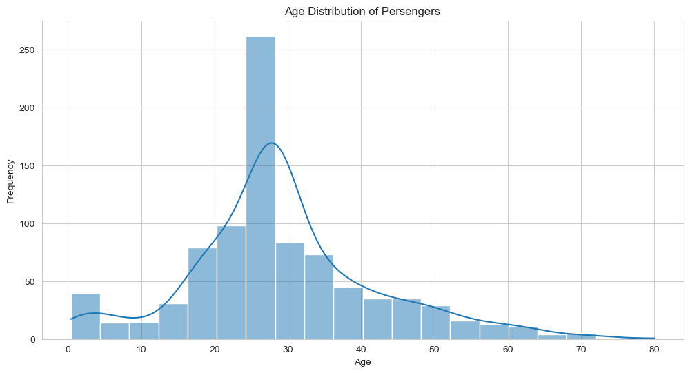

```python
# Get the Age Distribution of Persengers in a Histograph
plt.figure(figsize= (12, 6))
sns.histplot(data['Age'], bins=20, kde=True)
plt.title('Age Distribution of Persengers')
plt.xlabel('Age')
plt.ylabel('Frequency')
# plt.xticks(rotation=90)
```

From our analysis, we can deduce that:

1. The highest age range of the passengers fall between 25 and 28 years of Age.
2. The lowest age range of the passengers fall between 72 and 80 years of Age.
3. The majority of passengers are in the age range of 0 to 45

```python
def age_category(df):
    """
    Categorizes the 'Age' column in the DataFrame into age groups.

    Parameters:
    - df: DataFrame containing the (Titanic) dataset.

    Returns:
    - DataFrame with an additional column 'AgeGroup' containing the age labels.
    """

    # Define age categories and corresponding labels
    age_bins = [0, 12, 19, 30, 50, 65, 120]  # Define age groups: 0-12, 13-19, 20-30, 31-50, 51-65, 66-120
    age_labels = ['Child', 'Teenager', 'Young Adult', 'Adult', 'Middle Aged', 'Senior']


    # Create a new column 'AgeGroup' based on age categories
    df['AgeGroup'] = pd.cut(df['Age'], bins=age_bins, labels=age_labels, right=False)

    return df
pass

# titanic_data = pd.read_csv(r"C:\Users\USER PC\OneDrive\Documents\Business and Education\INGRYD\Project\Titanic-Dataset.csv")


titanic_data = age_category(titanic_data)

# Display the first few rows of the DataFrame with the new 'AgeGroup' column
print("Titanic dataset with AgeGroup column:")

print(titanic_data[['Age', 'AgeGroup']].head())
```

```
Titanic dataset with AgeGroup column:
    Age     AgeGroup
0  22.0  Young Adult
1  38.0        Adult
2  26.0  Young Adult
3  35.0        Adult
4  35.0        Adult
```

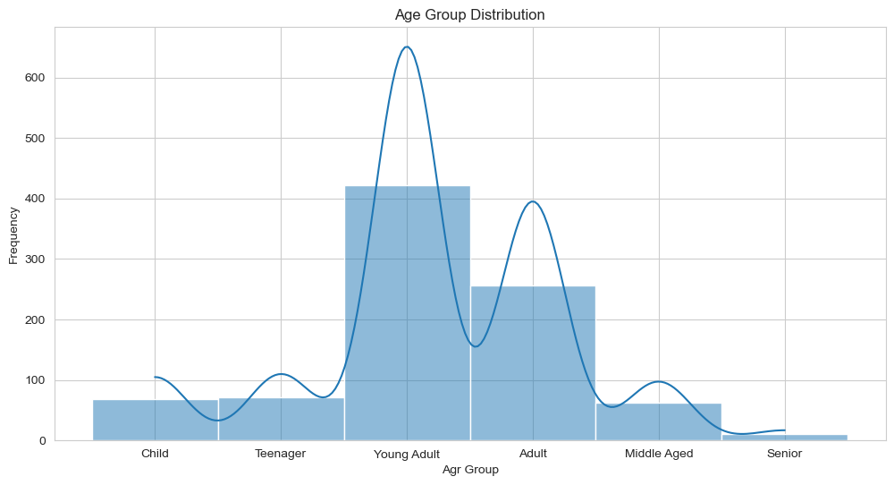

```python
# Let's visualize our Fare distribution with histplot.
plt.figure(figsize= (12, 6))
sns.histplot(titanic_data['AgeGroup'], bins=25, kde=True)
plt.title('Age Group Distribution')
plt.xlabel('Agr Group')
plt.ylabel('Frequency')
# plt.xticks(rotation=90)
plt.show()
```

[figure not shown]

```python
# Get the Sex Distribution of Persengers in a Pie Chart.
plt.figure(figsize= (6, 6))
plt.pie(titanic_data['Sex'].value_counts(), autopct='%1.1f%%', startangle=90)
# data['Sex'].value_counts().plot(kind='pie')
plt.title('Sex Distribution of Persengers')
plt.legend(['Female', 'Male'])
plt.axis('equal')
plt.show()
# plt.xticks(rotation=90)
```

From this chart above:

```
1. we have more male passengers than female
```

```python
# The count of passengers by gender
sex_count = titanic_data['Sex'].value_counts()
print(f"The Total Number Male Passengers is: {sex_count['male']}")
print(f"The Total Number Female Passengers is: {sex_count['female']}")
sex_count
```

```
The Total Number Male Passengers is: 577
The Total Number Female Passengers is: 314
```

```
Sex
male      577
female    314
Name: count, dtype: int64
```

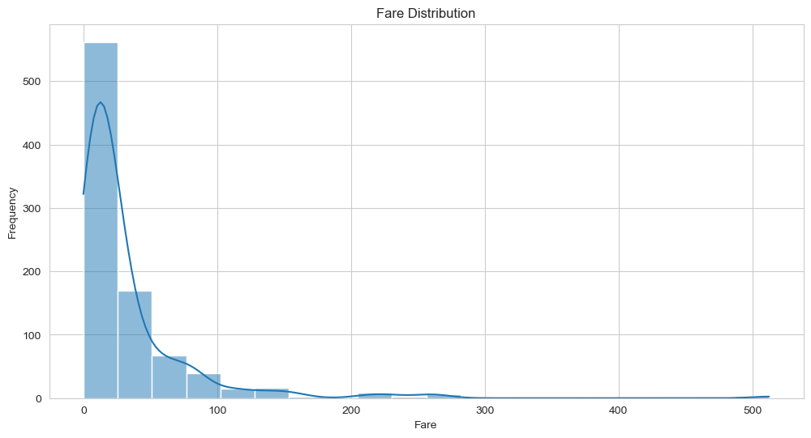

```python
# Let's visualize our Fare distribution with histplot.
plt.figure(figsize= (12, 6))
sns.histplot(data['Fare'], bins=20, kde=True)
plt.title('Fare Distribution')
plt.xlabel('Fare')
plt.ylabel('Frequency')
# plt.xticks(rotation=90)
plt.show()
```

From our analysis, we can deduce that:

1. More people purchased the low fare tickets
2. Approximately 580 passengers purchased the low fare ticke.
3. Less than 50 people purchased tickets with fare above 200 units

[figure not shown]

```python
#Get the Class Distribution of Persengers in a displot or a Pie chart
plt.figure(figsize= (6, 5))
plt.pie(titanic_data['Pclass'].value_counts(), autopct='%1.1f%%', startangle=90)
plt.legend(['Third Class', 'Second Class', 'First Class'])
plt.axis('equal')
plt.title('Class Distribution of Persengers')
'''sns.displot(titanic_data['Pclass'], bins=5, kde=True)
plt.xlabel('Pclass')
plt.ylabel('Frequency')'''
plt.show()
# plt.xticks(rotation=90)
```

From the chart:

1. There are more passengers (of 55.1% - approximately 490 passengers)on the 3rd class, affected by fare.
2. The 2nd class has the lowest number of passengers, approximately 190 passengers (20.7%).

```python
# The count of passengers per class
class_count = titanic_data['Pclass'].value_counts()
print(f"Total Number Passengers in the First Class is: {class_count[1]}")
print(f"Total Number Passengers in the Second Class is: {class_count[2]}")
print(f"Total Number Passengers in the Third Class is: {class_count[3]}")
```

```
Total Number Passengers in the First Class is: 216
Total Number Passengers in the Second Class is: 184
Total Number Passengers in the Third Class is: 491
```

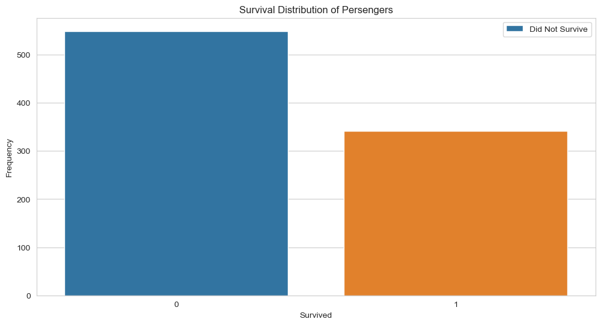

```python
plt.figure(figsize= (12, 6))
sns.countplot(x= 'Survived', data = titanic_data)
# sns.histplot(titanic_data['Survived'], bins=20, kde=True) # for histogram plot
plt.title('Survival Distribution of Persengers')
plt.xlabel('Survived')
plt.ylabel('Frequency')
plt.legend(['Did Not Survive', 'Survived'])
plt.show()
# plt.xticks(rotation=90)
```

From the chart above:

1. More passengers died in the crash
2. Approximately 345 passengers survived.

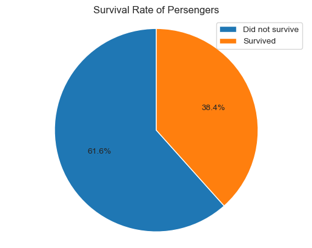

```python
# Get the Survival rate in percentage on a pie chart
plt.pie(titanic_data['Survived'].value_counts(), autopct='%1.1f%%', startangle=90)
plt.legend(['Did not survive', 'Survived'])
plt.axis('equal')
plt.title('Survival Rate of Persengers')
plt.show()
```

From our chart above:

- We deduced that 61.6% of the passengers, aboard the ill-fated vessel, did not survive the dissater
- While only 38.4% survived

```python
# The count of Survived rate of passengers. 0 = Died, 1 = survived.
counts = titanic_data['Survived'].value_counts()
print(f"Total death count is: {counts[0]}")
print(f"Total survival count is: {counts[1]}")
```

```
Total death count is: 549
Total survival count is: 342
```

```python
# Gender count
sex_counts = titanic_data['Sex'].value_counts()
print(f"Total male count is: {sex_counts['male']}")
print(f"Total female count is: {sex_counts['female']}")
```

```
Total male count is: 577
Total female count is: 314
```

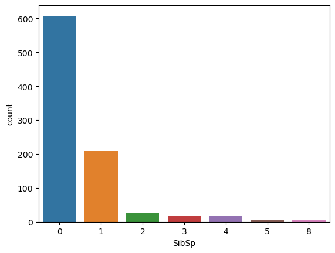

```python
sns.countplot(x= 'SibSp', data = titanic_data)
```

**2. Bivariate Analysis**

```python
# Let's define Sample Size, if the need to analyse a sample of the data arises
sample_size = 100
sample_data = data.sample(n=sample_size, random_state=42)
```

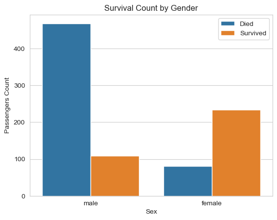

```python
# We are ploting a count plot to compare two variable Sex and survival
sns.countplot(x= 'Sex', data = titanic_data, hue='Survived')
plt.title('Survival Count by Gender')
plt.xlabel('Sex')
plt.ylabel('Passengers Count')
plt.legend(['Died', 'Survived'])
plt.show()
```

From the count plot above we can deduce that:

1. More females of approximately 240, survived
2. More males of approximately 480 did not survive.

```python
# The count of Survived rate of passengers by gender
class_survival_count = titanic_data.groupby('Sex')['Survived'].sum()
print("Total Survivors in by Gender:")
print(class_survival_count)
```

```
Total Survivors in by Gender:
Sex
female    233
male      109
Name: Survived, dtype: int64
```

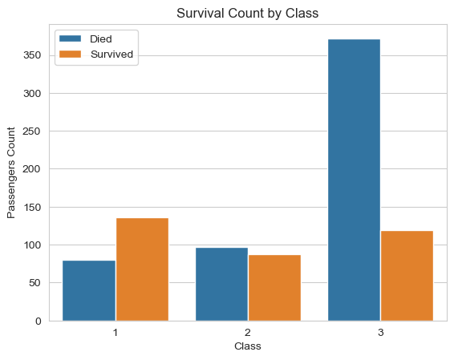

```python
# We are ploting a count plot to compare two variable: Pclass and Survival
sns.countplot(x= 'Pclass', data = titanic_data, hue='Survived')
plt.title('Survival Count by Class')
plt.xlabel('Class')
plt.ylabel('Passengers Count')
plt.legend(['Died', 'Survived'])
plt.show()
```

```python
# The count of Survived rate of passengers. 0 = Died, 1 = survived.
class_survival_count = titanic_data.groupby('Pclass')['Survived'].sum()
print("Total Survivors in each class:")
print(class_survival_count)
```

```
Total Survivors in each class:
Pclass
1    136
2     87
3    119
Name: Survived, dtype: int64
```

[figure not shown]

```python
# Represent the AegGroup against Survived in any two charts/plots for comparism
# 1. Spiral curves
age_labels = ['Child', 'Teenager', 'Young Adult', 'Adult', 'Middle Aged', 'Senior']
survival_status = [0, 1]

angles = np.linspace(0, 2*np.pi, len(age_labels))  # Angle for each AgeGroup
radii = np.linspace(0, 1, len(survival_status))     # Radius for each survival status

# Create a polar plot
fig, ax = plt.subplots(subplot_kw={'projection': 'polar'})

# Plot spiral curves for each survival status
for i, status in enumerate(survival_status):
    ax.plot(angles, radii[i] * np.ones_like(angles), label=f'Survived: {status}')

# Customize the plot
ax.set_theta_offset(np.pi/2)  # Rotate the plot to start from the top
ax.set_theta_direction(-1)     # Reverse the direction of rotation
ax.set_rticks([])              # Remove radial ticks
ax.set_xticks(angles)          # Set ticks at angles corresponding to AgeGroup
ax.set_xticklabels(age_labels, fontsize=8)  # Set labels for AgeGroup

# Add legend and title
ax.legend(loc='upper left')
plt.title('Spiral Curves for Survival and AgeGroup')

# Show the plot
plt.show()
```

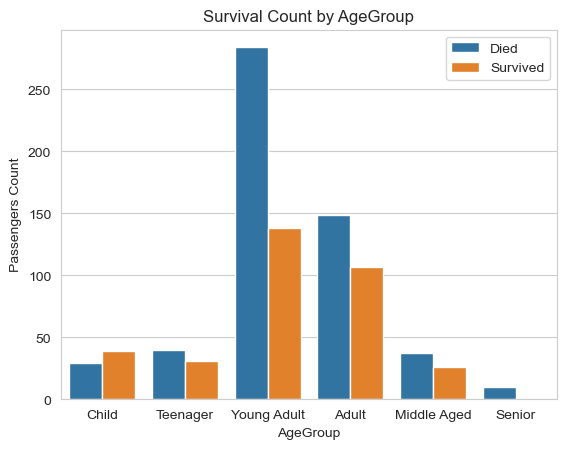

```python
# 2. countplot
sns.countplot(x= 'AgeGroup', data = titanic_data, hue='Survived')
plt.title('Survival Count by AgeGroup')
plt.xlabel('AgeGroup')
plt.ylabel('Passengers Count')
plt.legend(['Died', 'Survived'])
plt.show()
```

```python
# The count of Survived rate of passengers by age group
class_survival_count = titanic_data.groupby('AgeGroup')['Survived'].sum()
print("Total Survivors by age group:")
print(class_survival_count)
```

```
Total Survivors by age group:
AgeGroup
Child           39
Teenager        31
Young Adult    138
Adult          107
Middle Aged     26
Senior           1
Name: Survived, dtype: int64
```

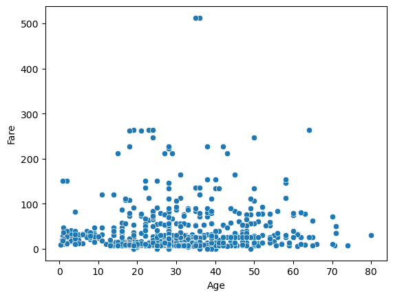

```python
sns.scatterplot(x='Age', y='Fare', data=titanic_data)
plt.show()
```

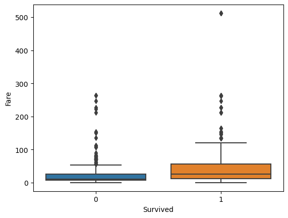

```python
sns.boxplot(x='Survived', y='Fare', data=titanic_data)
plt.show()
```

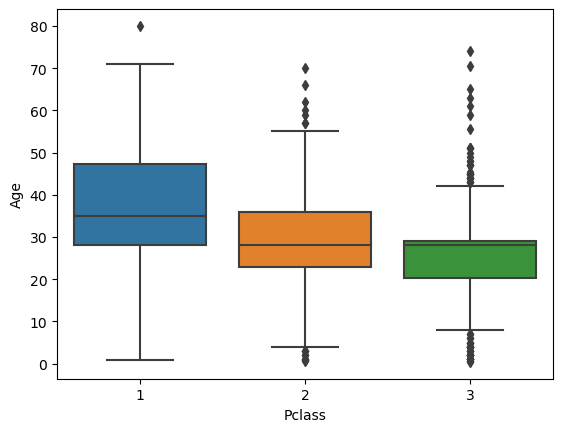

```python
sns.boxplot(x='Pclass', y='Age', data=titanic_data)
plt.show()
```

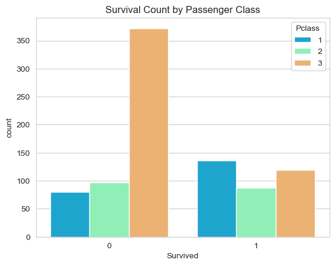

```python
sns.set_style('whitegrid')
sns.countplot(x= 'Survived', hue = 'Pclass', data = titanic_data, palette ='rainbow')
plt.title('Survival Count by Passenger Class')
```

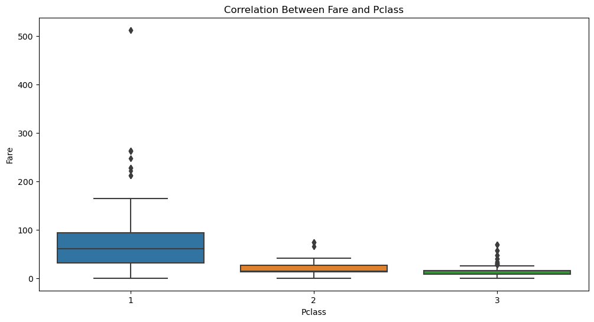

```python
# We are ploting a count plot to compare two variable class and fare
plt.figure(figsize=(12, 6))
sns.boxplot(x='Pclass', y='Fare', data=data)
plt.title("Correlation Between Fare and Pclass")
plt.xlabel("Pclass")
plt.ylabel("Fare")
plt.show()
```

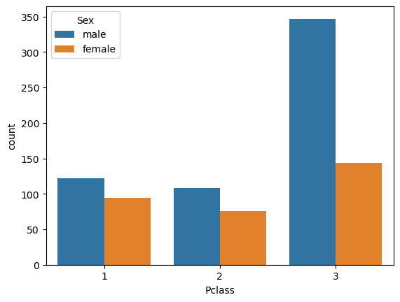

```python
sns.countplot(x='Pclass', hue='Sex', data=titanic_data)

plt.show()
```

From the Box plot above:

1. 1st class passengers paid the highest fare, followed by the second class passengers
2. The average cost of for the first class passengers is approximately 80 units

### Correlations: For All Numerical Value

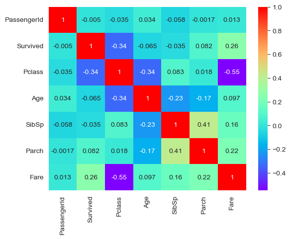

```python
# Exclude non-numeric columns before calculating correlation
numeric_data = titanic_data.select_dtypes(include=['int64', 'float64'])
corr_matrix = numeric_data.corr()

# Plot correlation matrix
sns.heatmap(corr_matrix, annot=True, cmap='rainbow')
plt.show()
```

```python
# Tabula representation (dataset), for correlation matrix of all numerical data
corr_matrix
```

|  | PassengerId | Survived | Pclass | Age | SibSp | Parch | Fare |
| --- | --- | --- | --- | --- | --- | --- | --- |
| PassengerId | 1.000000 | -0.005007 | -0.035144 | 0.034212 | -0.057527 | -0.001652 | 0.012658 |
| Survived | -0.005007 | 1.000000 | -0.338481 | -0.064910 | -0.035322 | 0.081629 | 0.257307 |
| Pclass | -0.035144 | -0.338481 | 1.000000 | -0.339898 | 0.083081 | 0.018443 | -0.549500 |
| Age | 0.034212 | -0.064910 | -0.339898 | 1.000000 | -0.233296 | -0.172482 | 0.096688 |
| SibSp | -0.057527 | -0.035322 | 0.083081 | -0.233296 | 1.000000 | 0.414838 | 0.159651 |
| Parch | -0.001652 | 0.081629 | 0.018443 | -0.172482 | 0.414838 | 1.000000 | 0.216225 |
| Fare | 0.012658 | 0.257307 | -0.549500 | 0.096688 | 0.159651 | 0.216225 | 1.000000 |

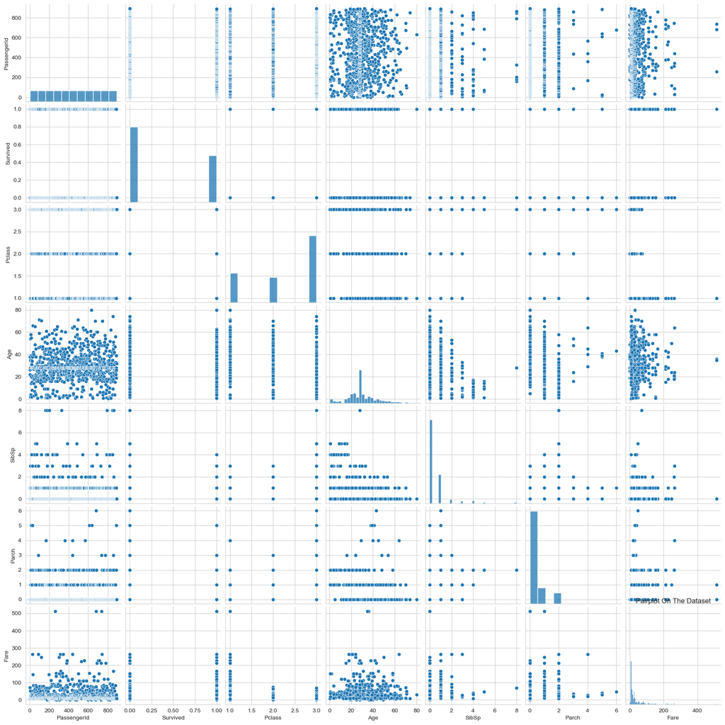

```python
# Do a Pairplot On The Dataset, for all the numerical columns
sns.pairplot(titanic_data)
plt.title('Pairplot On The Dataset')
plt.show()
```

# Label encoding

- *First, Let's drop some irrelevant column to this analysis.*

```python
data = titanic_data.drop(columns = ['Name', "Ticket", 'Cabin'], axis =1)
```

```python
from sklearn.preprocessing import LabelEncoder

cols = ['Sex', 'Embarked']

le = LabelEncoder()

for col in cols:
    data[col] = le.fit_transform(data[col])

data
```

|  | PassengerId | Survived | Pclass | Sex | Age | SibSp | Parch | Fare | Embarked | AgeGroup |
| --- | --- | --- | --- | --- | --- | --- | --- | --- | --- | --- |
| 0 | 1 | 0 | 3 | 1 | 22.0 | 1 | 0 | 7.2500 | 2 | Young Adult |
| 1 | 2 | 1 | 1 | 0 | 38.0 | 1 | 0 | 71.2833 | 0 | Adult |
| 2 | 3 | 1 | 3 | 0 | 26.0 | 0 | 0 | 7.9250 | 2 | Young Adult |
| 3 | 4 | 1 | 1 | 0 | 35.0 | 1 | 0 | 53.1000 | 2 | Adult |
| 4 | 5 | 0 | 3 | 1 | 35.0 | 0 | 0 | 8.0500 | 2 | Adult |
| ... | ... | ... | ... | ... | ... | ... | ... | ... | ... | ... |
| 886 | 887 | 0 | 2 | 1 | 27.0 | 0 | 0 | 13.0000 | 2 | Young Adult |
| 887 | 888 | 1 | 1 | 0 | 19.0 | 0 | 0 | 30.0000 | 2 | Young Adult |
| 888 | 889 | 0 | 3 | 0 | 28.0 | 1 | 2 | 23.4500 | 2 | Young Adult |
| 889 | 890 | 1 | 1 | 1 | 26.0 | 0 | 0 | 30.0000 | 0 | Young Adult |
| 890 | 891 | 0 | 3 | 1 | 32.0 | 0 | 0 | 7.7500 | 1 | Adult |

891 rows × 10 columns

### Now let us analys our objective:

**Based on Gender:**

Total Survivors in by Gender:

- female : 233
- male : 109

**Based on Class:**

Total Survivors in each class are;

- First Class : 136
- Second Class : 87
- Third Class : 119

**Based on Age:**

## Authors

* Daniel McDinna  
* Ifeoluwa Ajayi  
* Suleiman Adisa  
* Enesi Emmanuel  
* Kazeem Ahmed  
* Idowu Saidi